# Quarto, literate programming, and pseudocode

HES 505 Fall 2022: Session 3

Matt Williamson

## For today

1. Introduce literate programming
2. Describe pseudocode and its utility for designing an analysis
3. Introduce `Quarto` as a means of documenting your work
4. Practice workflow

# Literate Programming

## What is literate programming?

- Documentation containing code (not vice versa!)
- Direct connection between code and explanation
- Convey meaning to humans rather than telling computer what to do!
- Multiple “scales” possible

## Why literate programming?

- Your analysis scripts **are** computer software
- Integrate math, figures, code, and narrative in one place
- Explaining something helps you learn it

# Pseudocode

## Pseudocode and literate programming

- An informal way of writing the ‘logic’ of your program
- Balance between readability and precision
- Avoid *syntactic drift*

## Writing pseudocode

- Focus on statements
- Mathematical operations
- Conditionals
- Iteration
- Exceptions

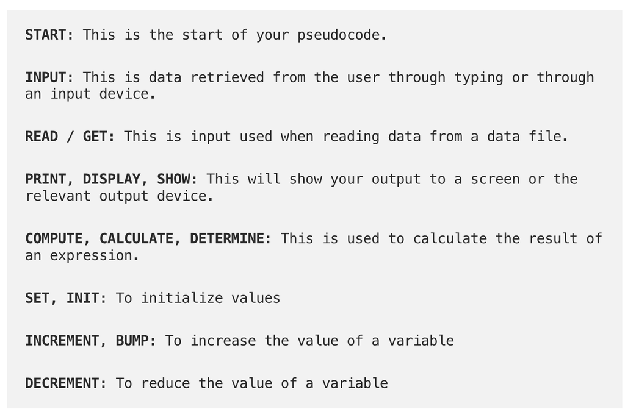

# Introducing Quarto

## What is Quarto?

- A multi-language platform for developing reproducible documents
- A ‘lab notebook’ for your analyses
- Allows transparent, reproducible scientific reports and presentations

## Key components

1. Metadata and global options: YAML
2. Text, figures, and tables: Markdown and LaTeX
3. Code: `knitr` (or `jupyter` if you’re into that sort of thing)

## YAML - Yet Another Markup Language

1. Allows you to set (or change) output format
2. Provide options that apply to the entire document
3. Spacing matters!

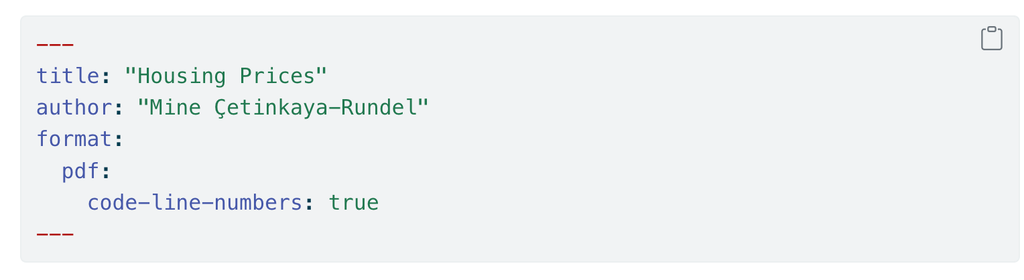

## Formatting Text

- Basic formatting via Markdown
- Fancier options using [Divs and spans](https://pandoc.org/MANUAL.html#divs-and-spans) via Pandoc
- Fenced Divs start and end with `:::` (can be any number `>3` but must match)

## Adding Code Chunks

- Use 3x `` ``` `` on each end
- Include the engine `{r}` (or python or Julia)
- Include options beneath the “fence” using a hashpipe (`#|`)

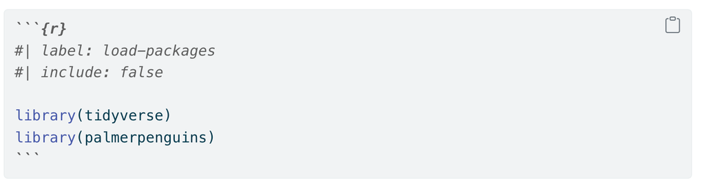